# Modulo 4. Interfaz de Looker Studio y visualizaciones

## Características para el diseño de un tablero efectivo para la vigilancia epidemiológica

Los tableros (dashboards) en general, como vimos en modulos anteriores, son herramientas visuales que agrupan y presentan información clave de una manera accesible. Estas herramientas permiten sintetizar grandes volúmenes de datos en visualizaciones claras y concisas.

En el proceso de diseño, es importante tener en cuenta el plan de análisis donde se explicitan los objetivos, las desiciones metodológicas y los pasos operativos. Por ello antes de comenzar el diseño del tablero, es crucial entender qué se quiere lograr con él, ya que esto guiará el diseño y la selección de métricas (medidas de resumen) e indicadores.

Algunas de sus ventajas en el campo de la vigilancia:

- Facilitan el monitoreo en tiempo real de los eventos de notificación obligatoria en salud
- Fundamentales para la gestión sanitaria y la toma de desiciones informada
- Simplifican la comunicación de resultados

## Consideraciones para el diseño

Organizar la información es una clave fundamental. Debe disponerse de manera que los elementos más importantes estén al frente, utilizando un diseño jerárquico. Optimizar las visualizaciones es igualmente necesario; esto implica usar gráficos y tablas adecuadas para cada tipo de dato, como gráficos de líneas para mostrar tendencias temporales y gráficos de barras para comparaciones.

A su vez, incluir elementos interactivos como filtros y segmentaciones permitirá a los usuarios explorar los datos de manera más profunda.

## Principios de visualización de datos

La efectividad en la visualización de datos puede guiarse por algunos principios clave. La carga cognitiva se refiere a la cantidad de esfuerzo mental que requiere procesar información nueva y compleja. En el contexto de la visualización de datos, una alta carga cognitiva puede dificultar la interpretación y comprensión de los gráficos.

1. Simplicidad: Priorizar la claridad y evitar elementos innecesarios.
2. Consistencia: Coherencia en el estilo (colores, fuentes y formatos).
3. Relevancia: Razón de ser de acuerdo a los objetivos del plan de análisis.
4. Uso de los espacios: El espacio en blanco se debe aprovechar para separar y organizar los elementos.

## Para añadir gráficos

Para incluir gráficos en nuestro tablero, luego de haber ya incorporado las fuentes de datos, podemos realizarlo desde el menú de nuestro proyecto.

[figure not shown]

Como paso previo a la selección de los gráficos y visualizaciones es fundamental comprender y clasificar nuestras variables (columnas de nuestas bases de datos). En líneas generales podemos clasificar cualquier tipo de variables como categóricas y numéricos. Los gráficos que utilicemos dependen de la [clasificación de nuestras variables en Looker Studio.](https://docs.cloud.google.com/looker/docs/studio/data-types?hl=es-419)

Te invitamos a explorar los [gráficos disponibles](https://docs.cloud.google.com/looker/docs/studio/types-of-charts-in-looker-studio?hl=es-419) en Looker Studio. Algunos de los mas utilizados en el campo de la vigilancia epidemiológica son:

- [Gráficos de Barras](https://docs.cloud.google.com/looker/docs/studio/bar-chart-and-column-chart-reference?hl=es-419)

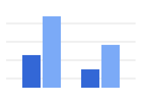

- [Gráficos de Líneas](https://docs.cloud.google.com/looker/docs/studio/time-series-reference?hl=es-419)

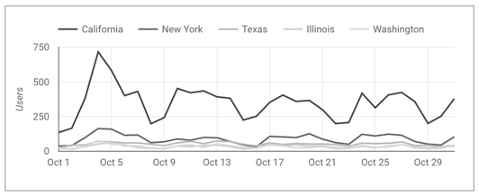

- [Gráficos Circular o Sectorial](https://docs.cloud.google.com/looker/docs/studio/pie-chart-reference?hl=es-419)

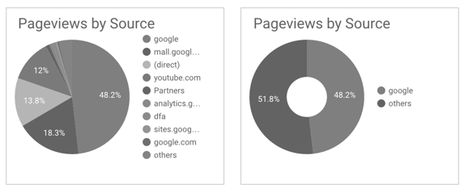

- [Cuadro de resultados o de evaluación](https://docs.cloud.google.com/looker/docs/studio/scorecard-reference?hl=es-419)

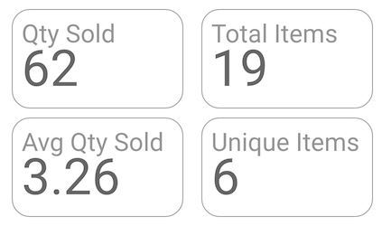

- [Tablas de resumen](https://docs.cloud.google.com/looker/docs/studio/table-reference?hl=es-419)

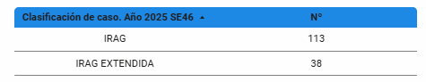

- [Mapas Coropléticos o temáticos](https://docs.cloud.google.com/looker/docs/studio/geo-chart-reference?hl=es-419)

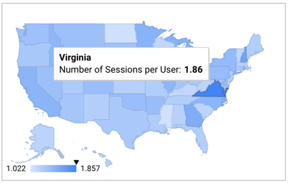

## Configuración y estilo

Una vez seleccionados los gráficos y las visualizaciones puede avanzarse en la configuración de cada gráfico y de su particular estilo que queremos darle. En el siguiente menú se presentan las opciones que podemos utilizar.

[figure not shown]

De acuedo al tipo de gráfico y de las variables seleccionadas podemos tener algunas diferencias. Sin embargo, en líneas generales estos son algunos de los elementos a tener en cuenta en la configuración.

- Fuente de datos

[figure not shown]

- Dimensión: Eje X

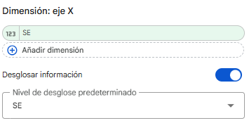

- Métrica: Eje Y

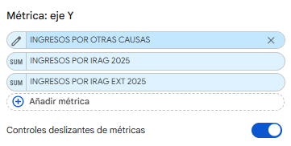

- Filtrar

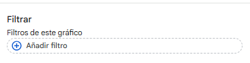

- Dimensión período

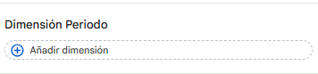

- Ordenar

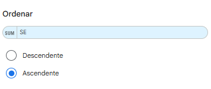

En lo relativo al estilo del gráfico puede editarse distintos elementos fundamentales de cualquier gráfico: título, leyendas de los ejes, fondos y bordes, etc.

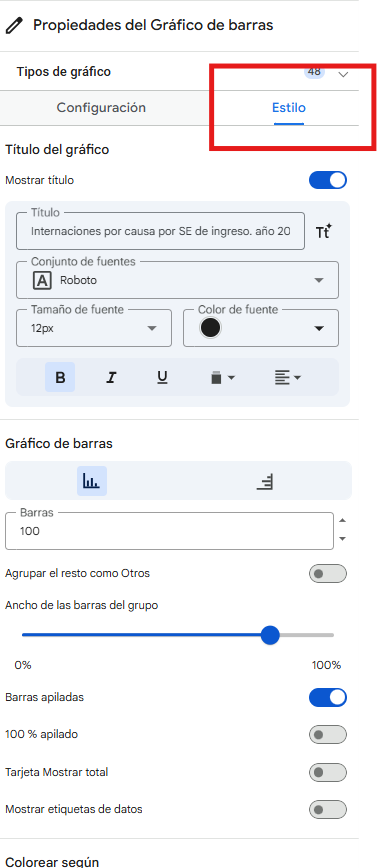

También es posible añadir [elementos de diseño estáticos en nuestro tablero](https://docs.cloud.google.com/looker/docs/studio/add-text-images-lines-and-shapes-to-your-reports?hl=es). Estos elementos puede ayudar a organizar el espacio y facilitar la comprensión de las visualizaciones que utilicemos. A su vez puede colocarse links de acceso a otras páginas web que complementen la información que estamos presentando.

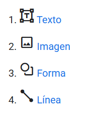

## Maquetación del tablero

Además de la configuración de las visualizaciones y gráficos (incluyendo todos los elementos necesarios para su comprensión: título, leyendas, etc.), la selección de estilos a utilizar, es conveniente no perder de vista el diseño global del tablero.

[figure not shown]

La combinación de visualizaciones y el diseño debe realizarse de acuerdo a nuestros objetivos planteados en el plan de análisis.